# PhenoRec Tutorial: Phenotype-Preserving Integration of scRNA-seq Data

In this tutorial, we demonstrate how to use **PhenoRec** for phenotype-preserving integration of single-cell RNA sequencing (scRNA-seq) data. Here, we use a publicly available type 1 diabetes (T1D) dataset accessed from the [CZ CELLxGENE Data Portal](https://cellxgene.cziscience.com/collections/51544e44-293b-4c2b-8c26-560678423380).

The dataset was generated in the study by [Fasolino et al.](https://www.nature.com/articles/s42255-022-00531-x), which profiled human pancreatic islets. Donors were classified into three phenotype groups:

- healthy controls;
- autoantibody-positive individuals without a clinical diagnosis of T1D (AAB+); and
- individuals with T1D.

The tutorial consists of four main stages:

1. Preprocess the scRNA-seq data.
2. Estimate latent cell states.
3. Apply PhenoRec to recover phenotype-associated signals.
4. Visualize the phenotype-preserving integrated data.

# 1 Load required packages

We first load the packages required for this tutorial.

```r
library(PhenoRec)
library(Seurat)
library(anndata)
library(ggplot2)
library(Matrix)
library(dplyr)
```

# 2 Load data

The downloaded T1D dataset is stored in AnnData format (`.h5ad`). We read it into R using the `anndata` package.

```r
data <- read_h5ad("T1D.h5ad")
data
```

```
## AnnData object with n_obs × n_vars = 69645 × 25629
##     obs: 'nCount_RNA', 'nFeature_RNA', 'percent.mt', 'RNA_snn_res.1.2', 'seurat_clusters', 'disease_state', 'cell_label', 'disease_ontology_term_id', 'tissue_ontology_term_id', 'assay_ontology_term_id', 'cell_type_ontology_term_id', 'is_primary_data', 'donor_id', 'development_stage_ontology_term_…
##     var: 'vst.mean', 'vst.variance', 'vst.variance.expected', 'vst.variance.standardized', 'vst.variable', 'feature_is_filtered', 'feature_name', 'feature_reference', 'feature_biotype', 'feature_length', 'feature_type'
##     uns: 'citation', 'organism', 'organism_ontology_term_id', 'schema_reference', 'schema_version', 'title'
##     obsm: 'X_pca', 'X_umap'
```

The AnnData object contains two components used in this tutorial:

- `data$X`: the cell-by-gene expression matrix.
- `data$obs`: cell-level metadata.

```r
metadata <- data$obs
data_matrix <- data$X

head(metadata)
```

```
##                    nCount_RNA nFeature_RNA percent.mt RNA_snn_res.1.2
## AAACCTGAGGTGTGGT-1      15507         2971  5.4298059               7
## AAACCTGCACGCCAGT-1       3694         1192  0.3519220              30
## AAACCTGCAGTCGATT-1      20676         4364  3.4726253               7
## AAACCTGTCACATACG-1      12103         3156  2.9496819              24
## AAACCTGTCACCCTCA-1      26144         4288  8.7018054               7
## AAACCTGTCCCGACTT-1       2240          809  0.3571429              30
##                    seurat_clusters disease_state  cell_label
## AAACCTGAGGTGTGGT-1               7       Control       alpha
## AAACCTGCACGCCAGT-1              30       Control  beta_major
## AAACCTGCAGTCGATT-1               7       Control       alpha
## AAACCTGTCACATACG-1              24       Control endothelial
## AAACCTGTCACCCTCA-1               7       Control       alpha
## AAACCTGTCCCGACTT-1              30       Control  beta_major
##                    disease_ontology_term_id tissue_ontology_term_id
## AAACCTGAGGTGTGGT-1             PATO:0000461          UBERON:0000006
## AAACCTGCACGCCAGT-1             PATO:0000461          UBERON:0000006
## AAACCTGCAGTCGATT-1             PATO:0000461          UBERON:0000006
## AAACCTGTCACATACG-1             PATO:0000461          UBERON:0000006
## AAACCTGTCACCCTCA-1             PATO:0000461          UBERON:0000006
## AAACCTGTCCCGACTT-1             PATO:0000461          UBERON:0000006
##                    assay_ontology_term_id cell_type_ontology_term_id
## AAACCTGAGGTGTGGT-1            EFO:0009899                 CL:0000171
## AAACCTGCACGCCAGT-1            EFO:0009899                 CL:0000169
## AAACCTGCAGTCGATT-1            EFO:0009899                 CL:0000171
## AAACCTGTCACATACG-1            EFO:0009899                 CL:0000115
## AAACCTGTCACCCTCA-1            EFO:0009899                 CL:0000171
## AAACCTGTCCCGACTT-1            EFO:0009899                 CL:0000169
##                    is_primary_data donor_id development_stage_ontology_term_id
## AAACCTGAGGTGTGGT-1            TRUE  HPAP022                     HsapDv:0000133
## AAACCTGCACGCCAGT-1            TRUE  HPAP022                     HsapDv:0000133
## AAACCTGCAGTCGATT-1            TRUE  HPAP022                     HsapDv:0000133
## AAACCTGTCACATACG-1            TRUE  HPAP022                     HsapDv:0000133
## AAACCTGTCACCCTCA-1            TRUE  HPAP022                     HsapDv:0000133
## AAACCTGTCCCGACTT-1            TRUE  HPAP022                     HsapDv:0000133
##                    sex_ontology_term_id
## AAACCTGAGGTGTGGT-1         PATO:0000383
## AAACCTGCACGCCAGT-1         PATO:0000383
## AAACCTGCAGTCGATT-1         PATO:0000383
## AAACCTGTCACATACG-1         PATO:0000383
```

[output cut: 15 more lines]

```
## AAACCTGTCCCGACTT-1      tissue type B pancreatic cell 10x 3' v2  normal female
##                                 tissue self_reported_ethnicity
## AAACCTGAGGTGTGGT-1 islet of Langerhans       European American
## AAACCTGCACGCCAGT-1 islet of Langerhans       European American
## AAACCTGCAGTCGATT-1 islet of Langerhans       European American
## AAACCTGTCACATACG-1 islet of Langerhans       European American
## AAACCTGTCACCCTCA-1 islet of Langerhans       European American
## AAACCTGTCCCGACTT-1 islet of Langerhans       European American
##                    development_stage observation_joinid
## AAACCTGAGGTGTGGT-1 39-year-old stage         =l0rBFlcHd
## AAACCTGCACGCCAGT-1 39-year-old stage         l`eSUKSXht
## AAACCTGCAGTCGATT-1 39-year-old stage         ufWJkbSP+c
## AAACCTGTCACATACG-1 39-year-old stage         g22yX2NZ~v
## AAACCTGTCACCCTCA-1 39-year-old stage         %SvM5<oWL`
## AAACCTGTCCCGACTT-1 39-year-old stage         9z5GB$~+V#
```

The metadata contain sample/batch identity (`donor_id`), phenotype information (`disease_state`), and cell-type annotations (`cell_type`). We convert batch and phenotype variables to character format.

```r
metadata$donor_id <- as.character(metadata$donor_id)
metadata$disease_state <- as.character(metadata$disease_state)
```

For visualization, we simplify the original cell-type annotations.

```r
map <- c(
  "pancreatic A cell" = "Alpha cells",
  "type B pancreatic cell" = "Beta cells",
  "endothelial cell" = "Endothelial cells",
  "pancreatic D cell" = "Delta cells",
  "pancreatic stellate cell" = "Stellate cells",
  "pancreatic ductal cell" = "Ductal cells",
  "unknown" = "unknown",
  "pancreatic acinar cell" = "Acinar cells",
  "pancreatic epsilon cell" = "Epsilon cells",
  "PP cell" = "PP cells"
)

metadata$cell_type_rename <- map[as.character(metadata$cell_type)]
```

# 3 Preprocess the scRNA-seq data

We construct a Seurat object from the expression matrix and metadata. The input matrix to `CreateSeuratObject()` is expected to have genes as rows and cells as columns, so the cell-by-gene matrix is transposed.

```r
seurat_data <- CreateSeuratObject(
  counts = t(data_matrix),
  assay = "RNA",
  meta.data = metadata
)
```

Cells without a defined cell-type annotation are excluded from this example.

```r
seurat_data <- subset(
  seurat_data,
  subset = cell_type_rename != "unknown"
)
```

We then preprocess the RNA measurements following the Seurat workflow. If you are unfamiliar with this workflow, please refer to the official tutorial.

```r
seurat_data <- FindVariableFeatures(
  seurat_data,
  nfeatures = 3000
)
```

```
## Finding variable features for layer counts
```

```r
seurat_data <- NormalizeData(seurat_data)
```

```
## Normalizing layer: counts
```

```r
# The data$X contains the normalized expression values. We restore these values to the RNA data slot
seurat_data@assays$RNA$data <-
  t(data_matrix[colnames(seurat_data), ])

seurat_data <- ScaleData(seurat_data)
seurat_data <- RunPCA(
  seurat_data,
  features = VariableFeatures(seurat_data),
  npcs = 200
)
```

[output not shown]

Here, 3,000 highly variable genes are selected. After scaling, PCA is used to obtain a lower-dimensional representation.

# 4 Visualize the unintegrated data

Before integration, we visualize the dataset. We construct a UMAP using the first 50 principal components.

```r
seurat_data <- RunUMAP(
  seurat_data,
  dims = 1:50
)
```

The UMAP embedding can be colored by cell type, sample, and phenotype.

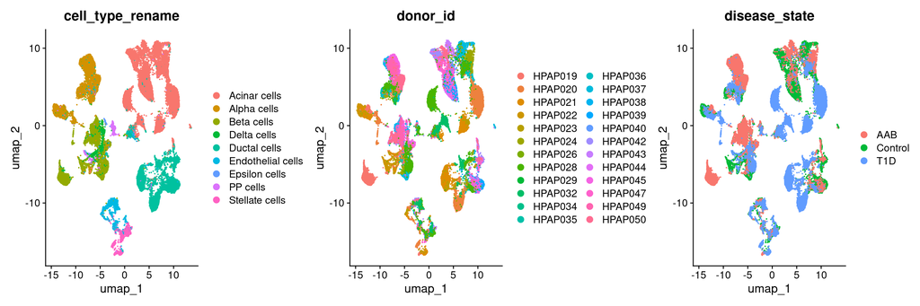

```r
DimPlot(
  seurat_data,
  group.by = "cell_type_rename"
) +
  DimPlot(
    seurat_data,
    group.by = "donor_id"
  ) +
  DimPlot(
    seurat_data,
    group.by = "disease_state"
  )
```

The donor-colored UMAP reveals substantial sample-specific batch variation in the unintegrated data, with cells from the same sample tending to cluster together and clear separation between samples. The phenotype-colored UMAP shows how cells are distributed across the three phenotype groups

# 5 Estimate latent cell states

PhenoRec first requires an estimate of the underlying cell-state representation, denoted by (Z) in the PhenoRec model. In the current implementation, conventional integration with Harmony is used to obtain this representation.

```r
harmony_z <- harmony::RunHarmony(
  seurat_data@reductions$pca@cell.embeddings,
  seurat_data@meta.data,
  "donor_id"
)
```

```
## Transposing data matrix
```

```
## Initializing state using k-means centroids initialization
```

```
## Harmony 1/10
```

```
## Harmony 2/10
```

```
## Harmony 3/10
```

```
## Harmony 4/10
```

```
## Harmony converged after 4 iterations
```

We store this representation in the Seurat object under the reduction name `estimate_z`.

```r
seurat_data[["estimate_z"]] <- CreateDimReducObject(
  embeddings = harmony_z,
  key = "estimatez_"
)
```

The reduction name `estimate_z` is required by the current implementation of PhenoRec, which retrieves the estimated latent cell states from this reduction.

# 6 Encode batch and phenotype information

PhenoRec requires encoded matrices of categorical batch and phenotype variables. These are generated using `encoding_function()`.

```r
encoding_data <- encoding_function(
  seurat_data = seurat_data,
  batch_id = "donor_id",
  phenotype_id = "disease_state"
)
```

Here, `batch_id = "donor_id"` specifies the batch variable, `phenotype_id = "disease_state"` specifies the phenotype of interest.

Depending on the study design and question of interest, the phenotype could represent:

- disease status;
- disease stage;
- treatment condition;
- longitudinal time point;
- another biological condition of interest.

# 7 Run PhenoRec

We now apply PhenoRec to the scRNA-seq data.

```r
input_data <- list(
  rna_data = seurat_data,
  encoding_data = encoding_data
)
```

```r
PhenoRec_result <- PhenoRec_RNA(
  input = input_data
)
```

```
## PhenoRec completed.
```

The principal output for downstream analysis is:

```r
integrated_data <- PhenoRec_result$integrated_data
```

`integrated_data` is the PhenoRec-recovered data, which removes unwanted batch variation while preserving biologically meaningful phenotype-associated variation. The integrated data can be used for visualization and downstream exploratory analyses.

# 8 Visualize the PhenoRec-recovered data

We create a new Seurat object containing the PhenoRec-recovered RNA data.

```r
integrated_assay <- CreateAssayObject(
  data = t(integrated_data)
)

integrated_obj <- CreateSeuratObject(
  counts = integrated_assay,
  assay = "RNA",
  meta.data = seurat_data@meta.data
)
integrated_obj <- ScaleData(integrated_obj)
integrated_obj <- RunPCA(
  integrated_obj,
  features = rownames(integrated_obj)
)
```

[output not shown]

```r
integrated_obj <- RunUMAP(
  integrated_obj,
  dims = 1:50
)
```

We visualize the UMAP by cell type, donor, and phenotype.

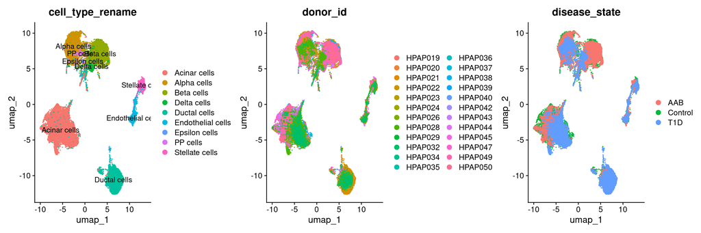

```r
DimPlot(
  integrated_obj,
  group.by = "cell_type_rename",
  label = TRUE
) +
  DimPlot(
    integrated_obj,
    group.by = "donor_id"
  ) +
  DimPlot(
    integrated_obj,
    group.by = "disease_state"
  )
```

These plots show that PhenoRec retained phenotype-associated structure, as reflected by clear separation between phenotype groups within specific cell types, indicating that the states of these cell populations differed across phenotype groups. Notably, beta cells exhibited a pronounced cell-state shift between T1D and healthy controls. This integrated representation preserves biologically meaningful phenotype signals and can be used to identify cell populations exhibiting pronounced state changes across phenotypes.